# Lesson 18: Inference for Two Proportions

Homework

- Word Document
- PDF Document

## Solutions

**Please note that the steps show rounded numbers, but that the final answers to the problems are calculated without rounding.**

Problem

Part

Solution

1

-

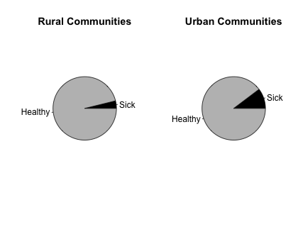

2

-

$n_1 \times \hat{p}_1 \geq 10 \text{ and } n_1 \times (1 - \hat{p}_1) \geq 10$  
$261\times(0.038) = 10 \geq 10 \text{ and } 261\times(1 - 0.038) = 251\geq 10$  
$n_2 \times \hat{p}_2 \geq 10 \text{ and } n_2 \times (1 - \hat{p}_2) \geq 10$  
$1614\times(0.103) = 166 \geq 10 \text{ and } 1614\times(1 - 0.103) = 1448\geq 10$  
The requirements are met.

3

-

( -0.092 , -0.037 ) We are 95 % confident that the true difference of the proportions of city children with hay fever and rural children with hay fever is between -0.092 and -0.037 .  
If you swapped the definition of groups 1 and 2, then you would get the same values with opposite signs: ( 0.037 , 0.092 ). This is also correct.

4

-

No. This means that it is plausible that the likelihood of a child contracting hay fever is different in the city than in rural areas.

5

-

$n_1 \times \hat{p}_1 \geq 10 \text{ and } n_1 \times (1 - \hat{p}_1) \geq 10$  
$200,000\times(0.0002) = 33 \geq 10 \text{ and } 200,000\times(1 - 0.0002) = 199,967\geq 10$  
$n_2 \times \hat{p}_2 \geq 10 \text{ and } n_2 \times (1 - \hat{p}_2) \geq 10$  
$200,000\times(0.0006) = 115 \geq 10 \text{ and } 200,000\times(1 - 0.0006) = 199,885\geq 10$  
The requirements are met.

6

-

( -0.00053 , -0.00029 ) We are 95 % confident that the true difference of the proportions of vaccinated children who developed polio and non-vaccinated children who developed polio is -0.00053 and -0.00029 .  
If you swapped the definition of groups 1 and 2, then you would get the same values with opposite signs: ( 0.00029 , 0.00053 ). This is also correct.

7

-

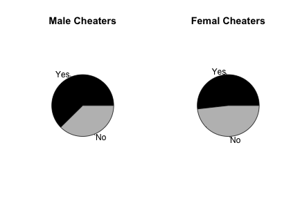

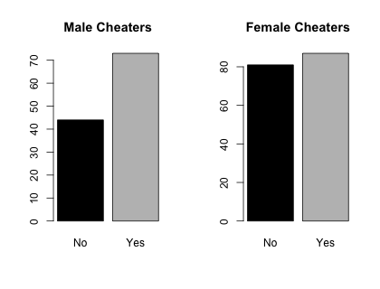

8

-

$n_1 \times \hat{p}_1 \geq 10 \text{ and } n_1 \times (1 - \hat{p}_1) \geq 10$  
$117\times(0.624) = 73 \geq 10 \text{ and } 117\times(1 - 0.624) = 44\geq 10$  
$n_2 \times \hat{p}_2 \geq 10 \text{ and } n_2 \times (1 - \hat{p}_2) \geq 10$  
$168\times(0.518) = 87 \geq 10 \text{ and } 168\times(1 - 0.518) = 81\geq 10$  
The requirements are met.

9

-

$H_0: p_1 = p_2$  
$H_a: p_1 > p_2$

10

-

$\hat{p_1} = 0.624$  
$\hat{p_2} = 0.518$

11

-

$z = 1.775$

12

-

$\text{p-value} = 0.038$

13

-

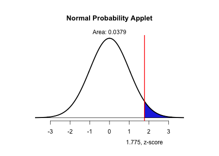

14

-

reject the null hypothesis

15

-

There is sufficient evidence to suggest that the proportion of men who cheat in college is greater than the proportion of women who cheat in college.

16

-

The p-value would double and be equal to 0.076 . This p-value is not significant and we would fail to reject the null hypothesis. With a two sided test we would not have sufficient evidence to conclude that there is a difference between the proportion of women and men who cheat in college.

17

-

$n_1 \times \hat{p}_1 \geq 10 \text{ and } n_1 \times (1 - \hat{p}_1) \geq 10$  
$1655\times(0.03) = 50 \geq 10 \text{ and } 1655\times(1 - 0.03) = 1605\geq 10$  
$n_2 \times \hat{p}_2 \geq 10 \text{ and } n_2 \times (1 - \hat{p}_2) \geq 10$  
$1652\times(0.019) = 31 \geq 10 \text{ and } 1652\times(1 - 0.019) = 1621\geq 10$  
The requirements are met.

18

-

$H_0: p_1 = p_2$  
$H_a: p_1 \neq p_2$

19

-

$\hat{p_1} = 0.03$  
$\hat{p_2} = 0.019$

20

-

$z = 2.129$

21

-

$\text{p-value} = 0.033$

22

-

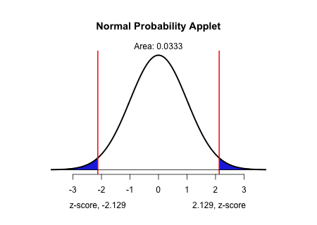

23

-

reject the null hypothesis

24

-

There is sufficient evidence to suggestthat the proportion of Clarinex subjects with dry mouth is different than the proportion of placebo subjects with dry mouth.